# life-expectancy

## Life Expectancy Prediction

The aim of this study is to investigate the determinants of life expectancy with the purpose of identifying the most significant factors that impact it. The selected factors will then be used as predictors in a predictive model. The analysis will involve a two-stage approach consisting of variable selection algorithms followed by regression algorithms, including LASSO and RIDGE.

To initiate the analysis, we will first import the dataset into R and proceed to examine its underlying structure.

```r
library(tidyverse) # metapackage of all tidyverse packages
library(dplyr)
library(ggplot2)
library(corrplot)
library(leaps)
library(caret)
library(glmnet)

# Load the data into a dataframe called 'life_expectancy'
life_expectancy  <- read.csv("https://raw.githubusercontent.com/maximsakhan/Life-Expectancy-Data/main/Life%20Expectancy%20Data.csv")
```

```r
# View the first few rows of the dataset
head(life_expectancy)

# Check the dimensions of the dataset (rows, columns)
dim(life_expectancy)

# Get a summary of the variables in the dataset
summary(life_expectancy)

# Check for missing values
sum(is.na(life_expectancy))
```

| Country | Year | Status | Life.expectancy | Adult.Mortality | infant.deaths | Alcohol | percentage.expenditure | Hepatitis.B | Measles | ... | Polio | Total.expenditure | Diphtheria | HIV.AIDS | GDP | Population | thinness..1.19.years | thinness.5.9.years | Income.composition.of.resources | Schooling |
| --- | --- | --- | --- | --- | --- | --- | --- | --- | --- | --- | --- | --- | --- | --- | --- | --- | --- | --- | --- | --- |
| Afghanistan | 2015 | Developing | 65.0 | 263 | 62 | 0.01 | 71.279624 | 65 | 1154 | ... | 6 | 8.16 | 65 | 0.1 | 584.25921 | 33736494 | 17.2 | 17.3 | 0.479 | 10.1 |
| Afghanistan | 2014 | Developing | 59.9 | 271 | 64 | 0.01 | 73.523582 | 62 | 492 | ... | 58 | 8.18 | 62 | 0.1 | 612.69651 | 327582 | 17.5 | 17.5 | 0.476 | 10.0 |
| Afghanistan | 2013 | Developing | 59.9 | 268 | 66 | 0.01 | 73.219243 | 64 | 430 | ... | 62 | 8.13 | 64 | 0.1 | 631.74498 | 31731688 | 17.7 | 17.7 | 0.470 | 9.9 |
| Afghanistan | 2012 | Developing | 59.5 | 272 | 69 | 0.01 | 78.184215 | 67 | 2787 | ... | 67 | 8.52 | 67 | 0.1 | 669.95900 | 3696958 | 17.9 | 18.0 | 0.463 | 9.8 |
| Afghanistan | 2011 | Developing | 59.2 | 275 | 71 | 0.01 | 7.097109 | 68 | 3013 | ... | 68 | 7.87 | 68 | 0.1 | 63.53723 | 2978599 | 18.2 | 18.2 | 0.454 | 9.5 |
| Afghanistan | 2010 | Developing | 58.8 | 279 | 74 | 0.01 | 79.679367 | 66 | 1989 | ... | 66 | 9.20 | 66 | 0.1 | 553.32894 | 2883167 | 18.4 | 18.4 | 0.448 | 9.2 |

1. 2938

2. 22

```
                Country          Year             Status     Life.expectancy
 Afghanistan        :  16   Min.   :2000   Developed : 512   Min.   :36.30
 Albania            :  16   1st Qu.:2004   Developing:2426   1st Qu.:63.10
 Algeria            :  16   Median :2008                     Median :72.10
 Angola             :  16   Mean   :2008                     Mean   :69.22
 Antigua and Barbuda:  16   3rd Qu.:2012                     3rd Qu.:75.70
 Argentina          :  16   Max.   :2015                     Max.   :89.00
 (Other)            :2842                                    NA's   :10
 Adult.Mortality infant.deaths       Alcohol        percentage.expenditure
 Min.   :  1.0   Min.   :   0.0   Min.   : 0.0100   Min.   :    0.000
 1st Qu.: 74.0   1st Qu.:   0.0   1st Qu.: 0.8775   1st Qu.:    4.685
 Median :144.0   Median :   3.0   Median : 3.7550   Median :   64.913
 Mean   :164.8   Mean   :  30.3   Mean   : 4.6029   Mean   :  738.251
 3rd Qu.:228.0   3rd Qu.:  22.0   3rd Qu.: 7.7025   3rd Qu.:  441.534
 Max.   :723.0   Max.   :1800.0   Max.   :17.8700   Max.   :19479.912
 NA's   :10                       NA's   :194
  Hepatitis.B       Measles              BMI        under.five.deaths
 Min.   : 1.00   Min.   :     0.0   Min.   : 1.00   Min.   :   0.00
 1st Qu.:77.00   1st Qu.:     0.0   1st Qu.:19.30   1st Qu.:   0.00
 Median :92.00   Median :    17.0   Median :43.50   Median :   4.00
 Mean   :80.94   Mean   :  2419.6   Mean   :38.32   Mean   :  42.04
 3rd Qu.:97.00   3rd Qu.:   360.2   3rd Qu.:56.20   3rd Qu.:  28.00
 Max.   :99.00   Max.   :212183.0   Max.   :87.30   Max.   :2500.00
 NA's   :553                        NA's   :34
     Polio       Total.expenditure   Diphtheria       HIV.AIDS
 Min.   : 3.00   Min.   : 0.370    Min.   : 2.00   Min.   : 0.100
 1st Qu.:78.00   1st Qu.: 4.260    1st Qu.:78.00   1st Qu.: 0.100
 Median :93.00   Median : 5.755    Median :93.00   Median : 0.100
 Mean   :82.55   Mean   : 5.938    Mean   :82.32   Mean   : 1.742
 3rd Qu.:97.00   3rd Qu.: 7.492    3rd Qu.:97.00   3rd Qu.: 0.800
 Max.   :99.00   Max.   :17.600    Max.   :99.00   Max.   :50.600
 NA's   :19      NA's   :226       NA's   :19
      GDP              Population        thinness..1.19.years
 Min.   :     1.68   Min.   :3.400e+01   Min.   : 0.10
 1st Qu.:   463.94   1st Qu.:1.958e+05   1st Qu.: 1.60
 Median :  1766.95   Median :1.387e+06   Median : 3.30
 Mean   :  7483.16   Mean   :1.275e+07   Mean   : 4.84
 3rd Qu.:  5910.81   3rd Qu.:7.420e+06   3rd Qu.: 7.20
 Max.   :119172.74   Max.   :1.294e+09   Max.   :27.70
 NA's   :448         NA's   :652         NA's   :34
 thinness.5.9.years Income.composition.of.resources   Schooling
 Min.   : 0.10      Min.   :0.0000                  Min.   : 0.00
 1st Qu.: 1.50      1st Qu.:0.4930                  1st Qu.:10.10
 Median : 3.30      Median :0.6770                  Median :12.30
 Mean   : 4.87      Mean   :0.6276                  Mean   :11.99
 3rd Qu.: 7.20      3rd Qu.:0.7790                  3rd Qu.:14.30
 Max.   :28.60      Max.   :0.9480                  Max.   :20.70
 NA's   :34         NA's   :167                     NA's   :163
```

2563

```r
# Handle missing data
life_expectancy <- na.omit(life_expectancy)

# Transform variables
life_expectancy$Year <- as.factor(life_expectancy$Year)
```

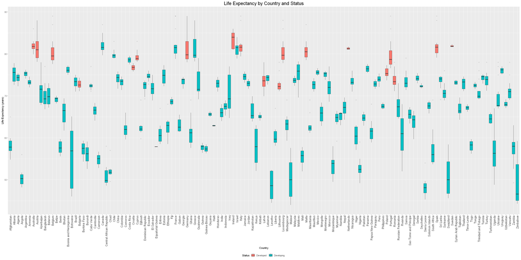

```r
# Visualize life expectancy by country and status
options(repr.plot.width = 30, repr.plot.height = 15)
ggplot(life_expectancy, aes(x = Country, y = Life.expectancy, fill = Status)) +
  geom_boxplot(outlier.alpha = 0.1) +
  labs(title = "Life Expectancy by Country and Status",
       x = "Country",
       y = "Life Expectancy (years)",
       fill = "Status") +
  theme(plot.title = element_text(size = 20, hjust = 0.5),
        axis.text.x = element_text(angle = 90, vjust = 0.5, hjust=1, size=12),
        legend.position = "bottom")
```

While the plot's message may not be immediately obvious, its primary objective is to underscore the influential role of a country's status in shaping life expectancy rates, as evident from the depicted data. Furthermore, it highlights that several nations, including Austria, Canada, Germany, Greece, and Ireland, consistently rank among the highest in terms of life expectancy.

```r
life_expectancy <- life_expectancy %>%
    select(-Country, - Year)
```

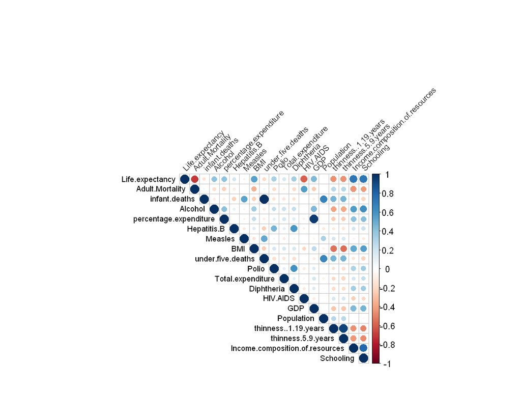

```r
life_expectancy$Status <- factor(life_expectancy$Status)

# Select numerical columns for correlation matrix
num_cols <- sapply(life_expectancy, is.numeric)
cor_mat <- cor(life_expectancy[, num_cols])

# Visualize correlation matrix
options(repr.plot.width = 10, repr.plot.height = 8)
par(mar = c(0.5, 0.5, 0.5, 0.5))
corrplot(cor_mat, method = "circle", type = "upper", tl.col = "black", tl.srt = 45, tl.cex = 0.9, cl.cex = 1)
```

```r
life_expectancy <- life_expectancy %>%
    select(-under.five.deaths, -percentage.expenditure, -thinness.5.9.years)
```

$$ \begin{align*} 1. & \text{Start with an empty set of selected predictor variables: } S = \emptyset. \\ 2. & \text{Initialize a model with no predictors: } M_0. \\ 3. & \text{For } k = 1 \text{ to } p \text{ (where } p \text{ is the total number of predictors):} \\ & \quad \text{a. For each predictor } X_j \text{ not in } S, \text{ fit the model } M_k \text{ with the predictors in } S \text{ plus } X_j \\ & \quad \text{and calculate a performance metric (e.g., AIC, BIC, or p-value).} \\ & \quad \text{b. Select the predictor } X_j \text{ that improves the performance metric the most and add it to } S. \\ 4. & \text{Continue the loop until a stopping criterion is met (e.g., no further improvement in the performance metric).} \\ 5. & \text{The final model contains the selected predictors: } M_{\text{final}}. \end{align*} $$

```r
# Stepwise forward selection omitting country and year columns
regfit.fwd <- regsubsets(Life.expectancy ~ ., data = life_expectancy, nvmax = ncol(life_expectancy)-1, method = "forward")
summary(regfit.fwd)
```

```
Subset selection object
Call: regsubsets.formula(Life.expectancy ~ ., data = life_expectancy,
    nvmax = ncol(life_expectancy) - 1, method = "forward")
16 Variables  (and intercept)
                                Forced in Forced out
StatusDeveloping                    FALSE      FALSE
Adult.Mortality                     FALSE      FALSE
infant.deaths                       FALSE      FALSE
Alcohol                             FALSE      FALSE
Hepatitis.B                         FALSE      FALSE
Measles                             FALSE      FALSE
BMI                                 FALSE      FALSE
Polio                               FALSE      FALSE
Total.expenditure                   FALSE      FALSE
Diphtheria                          FALSE      FALSE
```

[output cut: 76 more lines]

```r
# Handle missing data
life_expectancy_clean <- na.omit(life_expectancy)

# Split the data into training and testing sets
set.seed(123)
trainIndex <- createDataPartition(life_expectancy_clean$Life.expectancy,
                                   p = 0.8, list = FALSE)
trainData <- life_expectancy_clean[trainIndex, ]
testData <- life_expectancy_clean[-trainIndex, ]

# Define the predictor variables
predictors <- names(life_expectancy_clean)[4:19]

# Set the maximum number of predictors to consider
max_n <- length(predictors)

# Create an empty data frame to store the RMSE values
rmse_df <- data.frame(nvmax = 1:max_n, RMSE = NA)

predict.regsubsets = function(object, newdata, id, ...) {
    form = as.formula(object$call[[2]])
    mat = model.matrix(form, newdata)
    coefi = coef(object, id = id)
    mat[, names(coefi)] %*% coefi
}

# Run the stepwise forward algorithm for different values of nvmax
for (i in 1:max_n) {
    model <- regsubsets(Life.expectancy ~ ., data = trainData,
                      nvmax = i, method = "forward")
    pred <- predict(model, testData, i)
    rmse_df[i, "RMSE"] <- RMSE(pred, testData$Life.expectancy)
}
```

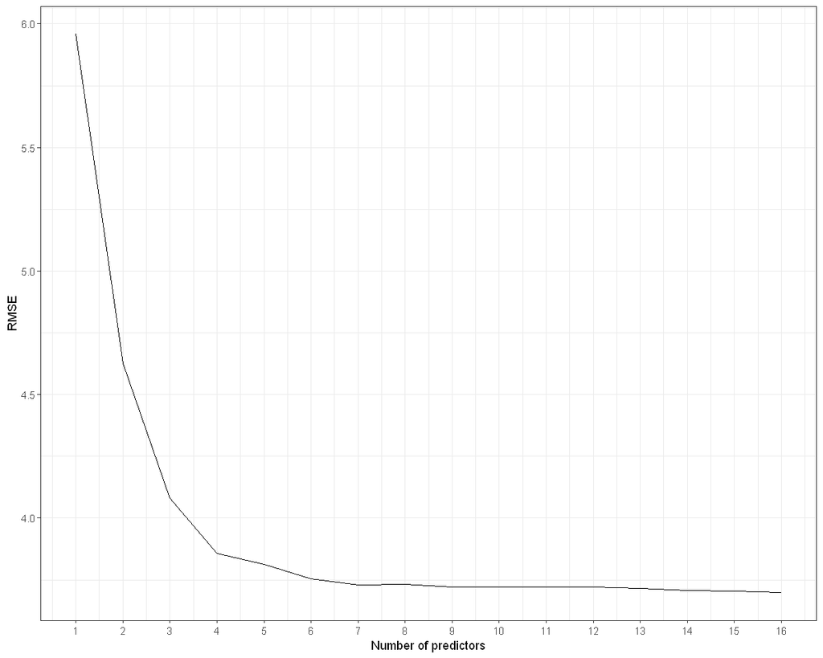

```r
# Plot the RMSE values against the number of predictors
library(ggplot2)
ggplot(rmse_df, aes(x = nvmax, y = RMSE)) +
  geom_line() +
  labs(x = "Number of predictors", y = "RMSE") +
  theme_bw() +
  scale_x_continuous(breaks = seq(1, max_n, by = 1))
```

As demonstrated by the stepwise forward variable selection algorithm, the ideal number of predictors appears to be seven. This conclusion is supported by a noticeable dip in the Root Mean Squared Error (RMSE) when considering the number of predictors. Beyond this point, the inclusion of additional predictors contributes to model complexity without a corresponding improvement in RMSE. Consequently, it is reasonable to assert that a robust model can be crafted by leveraging the insights gleaned from the summary of the regsubsets output, which highlights the significance of these seven variables.

```r
stepwise_model <- lm(Life.expectancy~Schooling+Income.composition.of.resources+Schooling*Income.composition.of.resources+
                     GDP+HIV.AIDS+Diphtheria+BMI+Adult.Mortality,data=trainData)
pred <- predict(stepwise_model, testData[,-1])
RMSE(pred, testData$Life.expectancy)
```

3.73098651095597

The optimized linear regression model demonstrates an RMSE of 3.73, indicating its effectiveness. An essential consideration in this model's development was the substantial correlation observed between the predictor variables, Income Composition Of Resources and Schooling. To address this multicollinearity, an interaction term was introduced into the model. This strategic step enables us to capture the nuanced interplay between predictor variables and understand how their effects depend on one another.

```r
X <- as.matrix(scale(trainData[,-c(1,2)]))
Y <- trainData$Life.expectancy

# Fit LASSO model
lasso_model <- glmnet(X, Y, alpha = 1)

# Fit Ridge model
ridge_model <- glmnet(X, Y, alpha = 0)

# Cross-validation for LASSO
cv_lasso <- cv.glmnet(X, Y, alpha = 1, nfolds = 5)

# Cross-validation for Ridge
cv_ridge <- cv.glmnet(X, Y, alpha = 0, nfolds = 5)

# Optimal lambda for LASSO
optimal_lambda_lasso <- cv_lasso$lambda.min

# Optimal lambda for Ridge
optimal_lambda_ridge <- cv_ridge$lambda.min
```

$$ \text{Lasso}(L1) = \lambda \sum_{j=1}^{p} |\beta_j| $$$$ \text{Ridge}(L2) = \lambda \sum_{j=1}^{p} \beta_j^2 $$

```r
# Refit the models with the optimal lambda
lasso_model_optimal <- glmnet(X, Y, alpha = 1, lambda = optimal_lambda_lasso)
ridge_model_optimal <- glmnet(X, Y, alpha = 0, lambda = optimal_lambda_ridge)

# Predictions using LASSO
predictions_lasso <- predict(lasso_model_optimal, newx = as.matrix(scale(testData[,-c(1,2)])))
rmse_lasso <- sqrt(mean((predictions_lasso - testData$Life.expectancy)^2))

# Predictions using Ridge
predictions_ridge <- predict(ridge_model_optimal, newx = as.matrix(scale(testData[,-c(1,2)])))
rmse_ridge <- sqrt(mean((predictions_ridge - testData$Life.expectancy)^2))

rmse_lasso
rmse_ridge
```

3.72243509911433

3.70021294694215

The rmse_lasso stands at 3.72, while rmse_ridge is 3.70, indicating that Ridge outperforms both Stepwise and Lasso. During 5-fold cross-validation, both Lasso and Ridge models exhibit superior performance compared to the Stepwise linear model. The final model to explore is the Elastic Net, which combines elements of both Lasso and Ridge models.

$$\text{Elastic Net}(L1L2) = \lambda_1 \sum_{j=1}^{p} |\beta_j| + \lambda_2 \sum_{j=1}^{p} \beta_j^2$$

```r
elastic_net_model <- glmnet(X, Y, alpha = 0.5)
cv_elastic_net <- cv.glmnet(X, Y, alpha = 0.5)
optimal_lambda <- cv_elastic_net$lambda.min
optimal_elastic_net_model <- glmnet(X, Y, alpha = 0.5, lambda = optimal_lambda)
predictions_elastic <- predict(optimal_elastic_net_model, newx = as.matrix(scale(testData[,-c(1,2)])))
rmse_elastic <- sqrt(mean((predictions_elastic - testData$Life.expectancy)^2))
rmse_elastic
```

3.72170917256619

```r
coef(ridge_model_optimal)
```

```
16 x 1 sparse Matrix of class "dgCMatrix"
                                         s0
(Intercept)                     69.24863636
Adult.Mortality                 -2.19493699
infant.deaths                   -0.34992497
Alcohol                         -0.24333721
Hepatitis.B                     -0.06454371
Measles                          0.12752456
BMI                              0.77134853
Polio                            0.24480589
Total.expenditure                0.18009699
Diphtheria                       0.40911842
HIV.AIDS                        -2.54337176
GDP                              0.79024494
Population                       0.13432047
thinness..1.19.years            -0.23273220
Income.composition.of.resources  1.78753973
Schooling                        2.36368634
```